# R Notebook

What makes a good predictive model? How do the methodologies of different models affect polling results and their reliability?

Morris’s model heavily weighs fundamentals/structural factors, with the knowledge that polls from many days before the election can be unreliable and without fundamentals, it can be difficult to predict voters’ actual behavior on election day. In order to avoid the pitfalls of “over-fit”, which is closely matched to historical examples, but fails when predicting future outcomes, Morris proposes two strategies. The first strategy is “elastic-net regularisation” by shrinking extraneous complexities of a model. The second strategy is “leave-one-out cross validation”, in which the model is split up and trained/tested on different chunks. What is good about shrinkage is that it tests the model 100 times and chooses the best degree of shrinkage, making the model far more reliable than if we were not to employ those two strategies. Morris also incorporates a combination of economic indicators rather than simply GDP growth, such as real disposable income and the stock market. For electoral college seats, he projects states’ “partisan lean” which is based on multiple factors, also used by Silver. One thing that may be missing from this list of factors is accounting for an established pattern of swing and unexpected swing voters within each state. Morris improves the accuracy of his model by weighing scenarios by probability of occurance, including correction for partisan non-response bias, and adjusting polls based on oscillations, accounting for uncertainty. I thought it was important when, in the state polls, Morris mentioned the portion of voters in a state who are white evangelical Christians, as they are a large portion of voters and are consistent in their voting (both in turnout and in choice). Like all other models, however, the quality of results from this model is contingent on factors such as the degree of polarization within elections, how stable economic conditions are, who the incumbent is, and as these factors vary, so does the margin of error. It is also overreliant on past precedent, lacking Silver’s more recent and arguably more relevant variables such as what % of a state’s votes are expected to be cast by mail. My question is how the model can be reliable in historical back-testing, but be lacking in predicting upcoming elections. Still, Morris openly acknowledges the existence of uncertainty in the model’s prior, which helps in trusting his approach more.

Silver’s methodology creates fundamentals formulas by looking at congressional funding, basic partisanship, among quality factors. What’s interesting about this model is its complexity: it somehow combines many polls and blends and layers them with other “empirically useful indicators” (fundamentals) for a probabilistic forecast.The degree of reliance upon polling differs for each model though, with the House model being less polling centric than in presidential races, which makes sense as voters may be more likely to make a decision last minute and also follow races with much less interest in voting for their representatives. The layers of the 538 forecast is distributed among 3 versions: Lite, Classic, and Deluxe, with 4 layers: polling, CANTOR, fundamentals, and expert forecast. They weigh models with a cocktail of simple and complicated formulas, but generally state partisanship and general ballot matter more and fundamentals, less. It is useful that the Classic version still incorporates past voting history, something that was missing from the Morris model. And similar to Morris, Silver accounts for error (although in a different way) by doing everything to avoid incorporating “bad” or “fake” polls into the model. Additionally, the likely voter, timeline, and house effects adjustments are key to addressing statistical bias from pollsters. The faults of this model may ironically be found in its strength of layers and complexity. What makes the model more accurate and unlike any other model is also a downfall. The addition of many factors may be contradictory to ratings found by polls, especially when there is such a heavy combination of polls and fundamentals. While Silver acknowledges the CANTOR method based on polls may be inferior to a fundamentals-based approach, he does not incporate that into the model. The errors of local context and incumbency status, which is referenced by Silver, can drive down the quality of the model. And in contrast to the Morris model, this model lacks a focus on historical example. Still, I was impressed that the model could continue to add in so many complexities that I underestimated such as basic partisanship and regional differences to improve its results.

All in all, both models are of high caliber, looking at partisan lean of a state or district and acknowledging their potential inaccuracies and accounting for them to the extent of what is in their control. Both look at fundamentals, however, the Silver model is focused on current trends, like information on the House incumbent in voting patterns and fundraising, wheras Morris holds a broader, less intricate lens of fundamentals, which is why I prefer the Morris methodology. All in all, the two models and methodologies offer a solid insight into how I can better my own forecast and holds consistency and improvement through their models, which I can then apply to my own project.

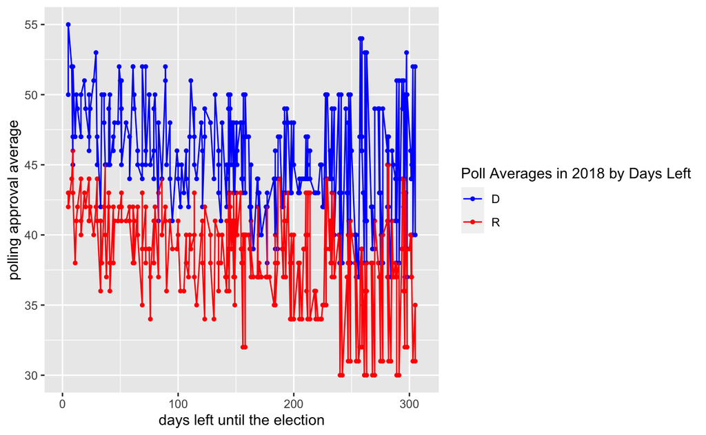

```r
library(tidyverse)

poll_df <- read_csv("polls_df.csv")
poll_df %>% filter(year == 2018) %>%
  ggplot(aes(x = days_until_election, y = support, color = party)) +
  geom_point(size = 1) + xlim(0,310) +
  geom_line() + #scale_x_date(date_labels = "%b, %Y")
  scale_color_manual(values = c("blue", "red"),
  name = "Poll Averages in 2018 by Days Left") + ylab("polling approval average") +
  xlab("days left until the election")
```

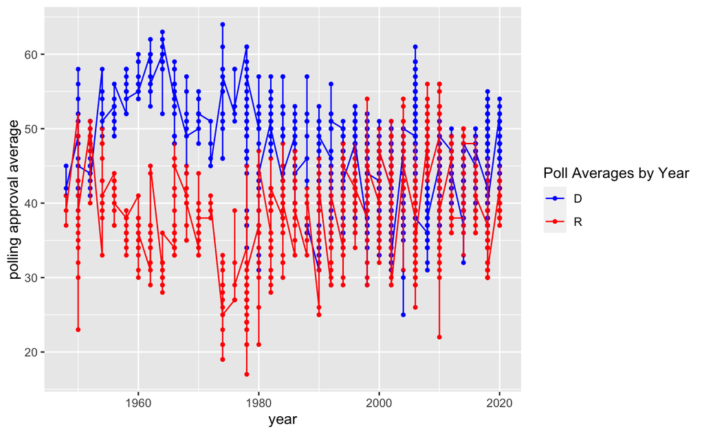

```r
poll_df %>%
  ggplot(aes(x = year, y = support, color = party)) +
  geom_point(size = 1) +
  geom_line() +
  scale_color_manual(values = c("blue", "red"),
  name = "Poll Averages by Year") + ylab("polling approval average") +
  xlab("year")
```